# causality_demo

Klaus Frieler

2026-08-11

## A contrived example

We simulated a data set based on the following DAG.

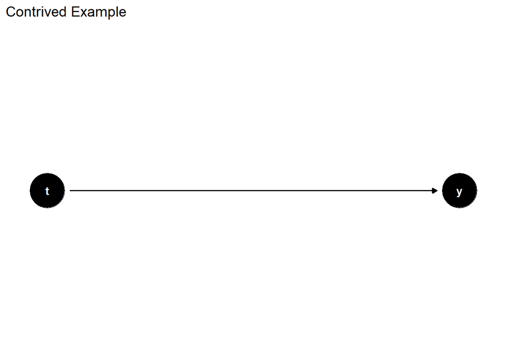

```r
ggdag(simple_dag_step1, layout = "time_ordered") +
  theme_dag()   +
  labs(title = "Contrived Example")
```

We simulated an observational experiment with a treatment t (0, 1, e.g, “playing music last week”) and an continuous outcome y (e.g., IQ). We have some data for it. What is the Average Treatment Effect?

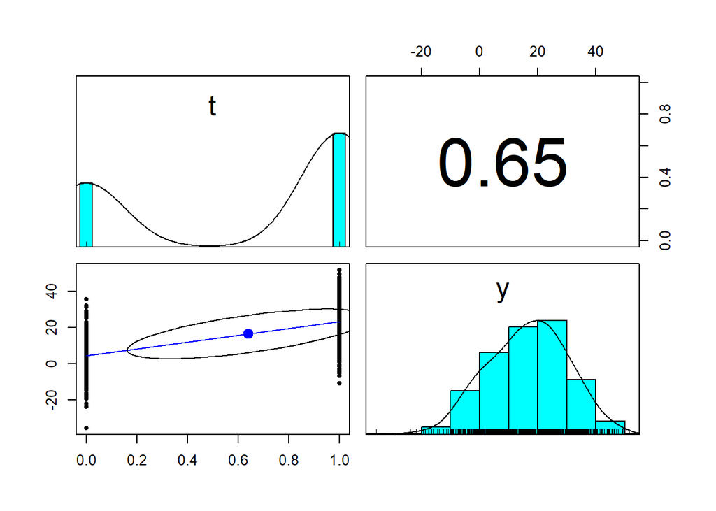

```r
simple %>%  select(t, y) %>% psych::pairs.panels()
```

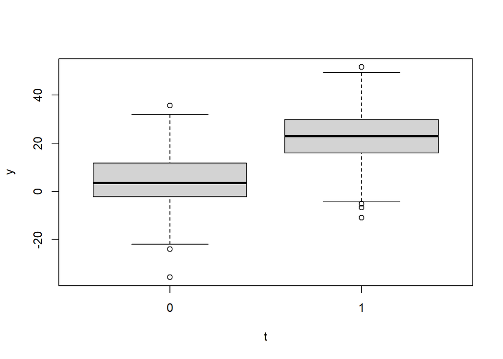

```r
#simple %>% with(., table(t))
simple %>% boxplot( y ~ t, data = .)
```

```r
simple %>% group_by(t) %>% summarise(m = mean(y))
```

```
## # A tibble: 2 × 2
##       t     m
##   <int> <dbl>
## 1     0  4.58
## 2     1 23.1
```

```r
simple %>%
  rstatix::t_test( y ~ t) %>% select(-c(group1, group2)) %>%
  bind_cols(simple %>%
  rstatix::cohens_d( y ~ t) %>% select(effsize)
)
```

```
## # A tibble: 1 × 7
##   .y.      n1    n2 statistic    df         p effsize
##   <chr> <int> <int>     <dbl> <dbl>     <dbl>   <dbl>
## 1 y       359   641     -26.9  728. 2.71e-111   -1.78
```

Great, a really strong effect. But we know and measured two covariates that might influence the outcome as well (e.g., SES, Working Memory)

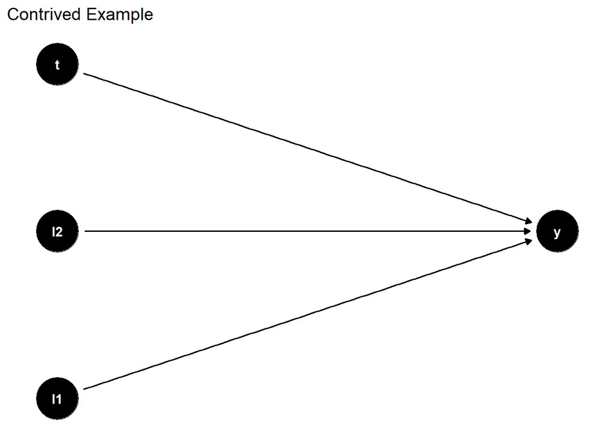

```r
ggdag(simple_dag_step2, layout = "time_ordered") +
  theme_dag()   +
  labs(title = "Contrived Example")
```

```r
simple %>% lm(y ~ t + l1 + l2, data = .) %>% summary()
```

```
##
## Call:
## lm(formula = y ~ t + l1 + l2, data = .)
##
## Residuals:
##      Min       1Q   Median       3Q      Max
## -16.1800  -3.5492   0.1343   3.2528  15.8473
##
## Coefficients:
##             Estimate Std. Error t value Pr(>|t|)
## (Intercept) -9.71276    0.36880 -26.336   <2e-16 ***
## t           10.07678    0.42521  23.698   <2e-16 ***
## l1           1.99191    0.03650  54.566   <2e-16 ***
## l2          -0.04148    0.03756  -1.104     0.27
## ---
## Signif. codes:  0 '***' 0.001 '**' 0.01 '*' 0.05 '.' 0.1 ' ' 1
##
## Residual standard error: 5.048 on 996 degrees of freedom
## Multiple R-squared:  0.8636, Adjusted R-squared:  0.8632
## F-statistic:  2102 on 3 and 996 DF,  p-value: < 2.2e-16
```

```r
ps_mod <- simple %>% glm(t ~ l1 + l2, family = "binomial", data = .)
sjPlot::tab_model(ps_mod)
```

|  | t |  |  |
| --- | --- | --- | --- |
| Predictors | Odds Ratios | CI | p |
| (Intercept) | 0.06 | 0.04 – 0.10 | **<0.001** |
| l1 | 1.36 | 1.30 – 1.43 | **<0.001** |
| l2 | 1.41 | 1.34 – 1.48 | **<0.001** |
| Observations | 1000 |  |  |
| R<sup>2</sup> Tjur | 0.434 |  |  |

```r
ps_mod %>% summary()
```

```
##
## Call:
## glm(formula = t ~ l1 + l2, family = "binomial", data = .)
##
## Coefficients:
##             Estimate Std. Error z value Pr(>|z|)
## (Intercept) -2.79309    0.24658  -11.33   <2e-16 ***
## l1           0.30817    0.02374   12.98   <2e-16 ***
## l2           0.34100    0.02520   13.53   <2e-16 ***
## ---
## Signif. codes:  0 '***' 0.001 '**' 0.01 '*' 0.05 '.' 0.1 ' ' 1
##
## (Dispersion parameter for binomial family taken to be 1)
##
##     Null deviance: 1305.7  on 999  degrees of freedom
## Residual deviance:  809.8  on 997  degrees of freedom
## AIC: 815.8
##
## Number of Fisher Scoring iterations: 5
```

```r
ps_mod %>% performance::r2_tjur()
```

```
## Tjur's R2
## 0.4337364
```

This seems to be the case. Let’s try some propensity score weighting.

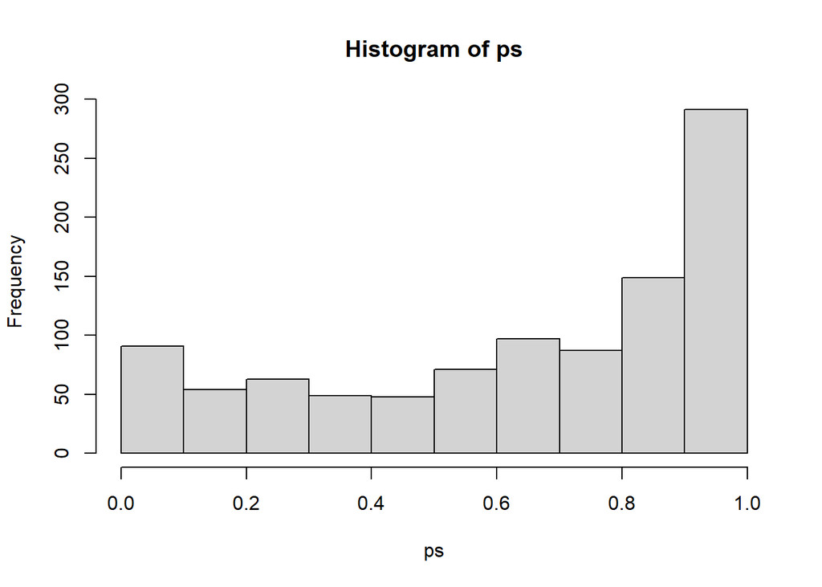

```r
ps <- ps_mod %>% predict(type = "response")
hist(ps)
```

```r
as.integer(ps > .5) %>% table()
```

```
## .
##   0   1
## 305 695
```

```r
table(simple$t)
```

```
##
##   0   1
## 359 641
```

Let’s try IPW regression using propensity score, without covariates.

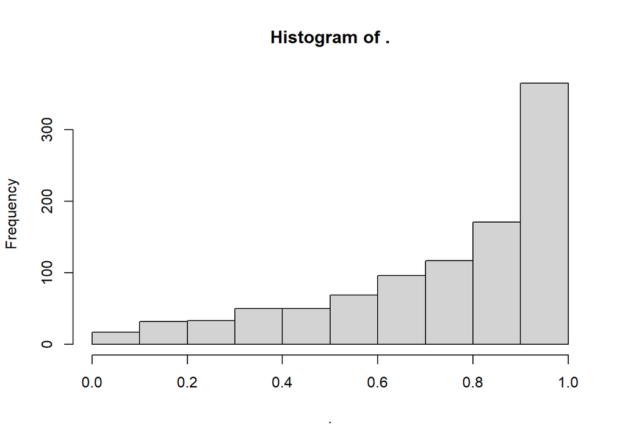

```r
simple_ext <- simple %>% group_by(t) %>%
  mutate(rel_f = n()/nrow(.)) %>%
  ungroup() %>%
  mutate(weights = t * ps + (1 -t) * (1 - ps),
         stab_weights = rel_f * (t * ps + (1 -t) * (1 - ps)))

simple_ext$weights %>% hist()
```

```r
ipw_prop1 <- simple_ext %>%
           lm(y ~ t, weights = weights, data = .) %>% summary()
ipw_prop1
```

```
##
## Call:
## lm(formula = y ~ t, data = ., weights = weights)
##
## Weighted Residuals:
##     Min      1Q  Median      3Q     Max
## -37.558  -5.836  -0.445   5.354  27.133
##
## Coefficients:
##             Estimate Std. Error t value Pr(>|t|)
## (Intercept)   2.4116     0.5733   4.207 2.82e-05 ***
## t            21.8902     0.6898  31.735  < 2e-16 ***
## ---
## Signif. codes:  0 '***' 0.001 '**' 0.01 '*' 0.05 '.' 0.1 ' ' 1
##
## Residual standard error: 8.669 on 998 degrees of freedom
## Multiple R-squared:  0.5023, Adjusted R-squared:  0.5018
## F-statistic:  1007 on 1 and 998 DF,  p-value: < 2.2e-16
```

```r
ipw_prop2 <- simple_ext %>%
           lm(y ~ t, weights = stab_weights, data = .) %>% summary()
ipw_prop2
```

```
##
## Call:
## lm(formula = y ~ t, data = ., weights = stab_weights)
##
## Weighted Residuals:
##      Min       1Q   Median       3Q      Max
## -24.3752  -4.1845  -0.3434   3.9320  21.7233
##
## Coefficients:
##             Estimate Std. Error t value Pr(>|t|)
## (Intercept)   2.4116     0.7131   3.382 0.000748 ***
## t            21.8902     0.7976  27.446  < 2e-16 ***
## ---
## Signif. codes:  0 '***' 0.001 '**' 0.01 '*' 0.05 '.' 0.1 ' ' 1
##
## Residual standard error: 6.462 on 998 degrees of freedom
## Multiple R-squared:  0.4301, Adjusted R-squared:  0.4296
## F-statistic: 753.3 on 1 and 998 DF,  p-value: < 2.2e-16
```

So, this didn’t work. Let’s add covariates

```r
ipw_prop3 <- simple_ext %>%
           lm(y ~ t + l1 + l2, weights = weights, data = .) %>% summary()
ipw_prop3
```

```
##
## Call:
## lm(formula = y ~ t + l1 + l2, data = ., weights = weights)
##
## Weighted Residuals:
##      Min       1Q   Median       3Q      Max
## -16.0374  -2.7887   0.1599   2.6866  15.8037
##
## Coefficients:
##             Estimate Std. Error t value Pr(>|t|)
## (Intercept) -9.81302    0.36246 -27.074   <2e-16 ***
## t           10.51365    0.53338  19.711   <2e-16 ***
## l1           1.97164    0.03867  50.992   <2e-16 ***
## l2          -0.07073    0.04017  -1.761   0.0786 .
## ---
## Signif. codes:  0 '***' 0.001 '**' 0.01 '*' 0.05 '.' 0.1 ' ' 1
##
## Residual standard error: 4.325 on 996 degrees of freedom
## Multiple R-squared:  0.8764, Adjusted R-squared:  0.876
## F-statistic:  2354 on 3 and 996 DF,  p-value: < 2.2e-16
```

Not so much changes.

Let’s try matching, “full” and then CEM.

```
## Ignoring unknown labels:
## • shape : "p-level"
```

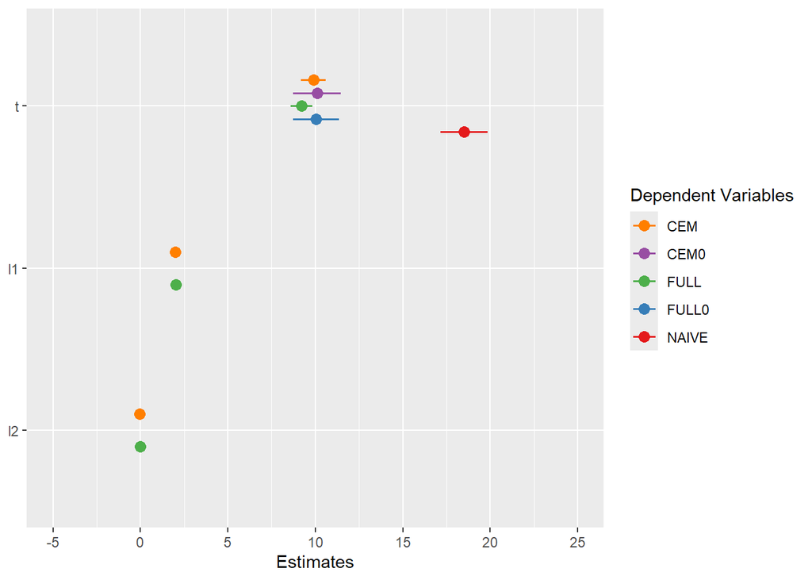

```r
  match_full <- simple %>%
    MatchIt::matchit(t ~ l1 + l2, method = "full",
                     distance = "glm",
                     link = "logit", data  =.)

  match_cem <- simple %>%
    MatchIt::matchit(t ~ l1 + l2,
                     method = "cem", data  =.)
  simple_full <- match_data(match_full)
  simple_cem <- match_data(match_cem)
  fit_full <- simple_full %>%
    lm(y ~ t + l1 + l2,
       weights = weights,
       data = .)

  fit_full0 <- simple_full %>%
    lm(y ~ t,
       weights = weights,
       data = .)
  fit_cem <- simple_cem %>%
    lm(y ~ t + l1 + l2,
       weights = weights,
       data = .)

  fit_cem0 <- simple_cem %>%
    lm(y ~ t,
       weights = weights,
       data = .)
sjPlot::plot_models(fit_cem, fit_cem0, fit_full, fit_full0, lm(y ~t, data = simple), m.labels = c("CEM", "CEM0", "FULL", "FULL0", "NAIVE"))
```

Finally, let’s try TMLE.

```r
mod1 <- simple %>%
  lmtp_tmle(
    trt = "t",
    outcome = "y",
    outcome_type = "continuous",
    baseline = c("l1", "l2"),
    shift = static_binary_on
  )
mod0 <- simple %>% lmtp_tmle(
  trt = "t",
  outcome = "y",
  outcome_type = "continuous",
  baseline = c("l1", "l2"),
  shift = static_binary_off
)
lmtp_contrast(mod1, ref = mod0)
```

```
## LMTP Contrast: additive
```

```
## Null hypothesis: theta == 0
```

```
##
##   shift  ref estimate std.error conf.low conf.high p.value
## 1  20.1 10.3     9.81     0.361      9.1      10.5  <0.001
```

So what is the truth? Here is the code to generate the simulated data. The true ATE is 10.

```
simulate_simple_example <- function(n = 1000,
                                    seed = global_seed,
                                    threshold = .1,
                                    cov_rel = 0){
  set.seed(seed)
  simdat <- tibble(l1 = rnorm(n, 10, 5))

  #use some normal distribution to defined treatment
  a.lin <- simdat$l1 - 10
  b.lin <- rnorm(n, 2, 5)

  #c.lin will be unobserved
  c.lin <- rnorm(n, 1, 5)

  #logistic experssion to defone probality to be treated
  pa <- exp(a.lin + b.lin + c.lin)/(1 + exp(a.lin + b.lin + c.lin))

  #simulate binary treatment based on probability to treat, which in turn is based on 2 obversed and on unobserved covariate
  simdat$t <- rbinom(n, 1, prob = pa)

  #add reandom treatment for whatever reasons
  simdat$r <- sample(c(-1,1), nrow(simdat), replace = T)

  #outcome
  simdat$y <- 10 * simdat$t + 2 * simdat$l1 + rnorm(n, -10, 5)

  #Covariate l1 with measurement error based on cov_rel (covariate reliability)
  simdat$l1_me <- simdat$l1 + rnorm(n, 0, cov_rel)

  #covariate l2
  simdat$l2 <- b.lin

  #Covariate l2 with measurement error, based on cov_rel)
  simdat$l2_me <- b.lin + rnorm(n, 0, cov_rel)

  #change threshold/2 percents of treatments
  shuffle_idx <- which(runif(nrow(simdat)) > (1 - threshold))
  simdat$t_me <- simdat$t
  simdat$t_me[shuffle_idx] <- sample(c(0, 1), length(shuffle_idx), replace = T)

  #add a collider, for education purposes
  simdat <- simdat %>% mutate(z = scale((y + l1 * l2))[,1] + rnorm(nrow(simdat), 10, 1))
  #add ids for completeness
  simdat$id <- 1:nrow(simdat)
  simdat
}
```

This includes also some more variables, i.e., measurement error for treatment `t_me`, for covaviates `l1_me`, `l2_me' as well as a collider`z`depending on`y`,`l1`and`l2`.

Let’s try different estimations methods for different combinations of theses variables and compare. We used clean (trt = `clean`) or noisy treatment (about `5%` wrong treatments, trt = `noisy`), with or without measurement error for `l1` and `l2` (with_measurement error `none`or `some`), and the following methods

- simple linear regression (method = `none`)
- tmle (method = `tmle`)
- full matching fromt the `matchIt` package (method = `fuil matching`) with or without weights (weights = `none` or weights = `IPW`)
- Coarsend Exact Matching (CEM) from the `matchIt` package (method = `CEM`) with or without weights (weights = `none` or weights = `IPW`)

with the following model variants

- covariates `l1`and `l2` (spec = `covariates`)
- wrong covariates `z` and `l2` (spec = `wrong covariates`)
- covariates `l1`, `l2`and collider `z` (spec = `covariates + collider`)

`ref` is the mean in the non-treated group, and `shift` is the mean in the treated group, either raw means or as estimated by the `lmtp_tmle` function. `ATE`is the estimated average treatment effect.

```r
comp_ATE_raw <- comp_ATE_simple_dags(with_measurement_error = F, data = simple)
comp_ATE_me <- comp_ATE_simple_dags(with_measurement_error = T, data = simple)
comp_ATE <- bind_rows(comp_ATE_raw, comp_ATE_me) %>%
  rename(ATE = estimate) %>% mutate(difference = ATE - 10)  %>%
  select(ATE, difference, ref, shift, trt, measurement_error = with_measurement_error,
         method, spec, trt, weights, everything())

comp_ATE %>%   arrange(abs(difference)) %>% sjPlot::tab_df()
```

| ATE | difference | ref | shift | trt | measurement_error | method | spec | weights | std.error | statistic | p.value | conf.low | conf.high |
| --- | --- | --- | --- | --- | --- | --- | --- | --- | --- | --- | --- | --- | --- |
| 10.02 | 0.02 | 4.58 | 23.09 | clean | none | full matching | no covariates | IPW | 0.67 | 14.99 | 0.00 | NA | NA |
| 10.02 | 0.02 | 4.58 | 23.09 | clean | some | full matching | no covariates | IPW | 0.67 | 14.99 | 0.00 | NA | NA |
| 9.97 | -0.03 | 5.95 | 21.62 | clean | none | CEM matching | covariates | none | 0.43 | 22.99 | 0.00 | NA | NA |
| 9.97 | -0.03 | 5.95 | 21.62 | clean | some | CEM matching | covariates | none | 0.43 | 22.99 | 0.00 | NA | NA |
| 10.08 | 0.08 | 4.58 | 23.09 | clean | none | none | covariates | none | 0.43 | 23.70 | 0.00 | NA | NA |
| 10.08 | 0.08 | 4.58 | 23.09 | clean | none | full matching | covariates | none | 0.43 | 23.70 | 0.00 | NA | NA |
| 10.08 | 0.08 | 4.58 | 23.09 | clean | some | none | covariates | none | 0.43 | 23.70 | 0.00 | NA | NA |
| 10.08 | 0.08 | 4.58 | 23.09 | clean | some | full matching | covariates | none | 0.43 | 23.70 | 0.00 | NA | NA |
| 9.89 | -0.11 | 5.95 | 21.62 | clean | none | CEM matching | covariates | IPW | 0.36 | 27.15 | 0.00 | NA | NA |
| 9.89 | -0.11 | 5.95 | 21.62 | clean | none | CEM matching | no covariates | IPW | 0.36 | 27.15 | 0.00 | NA | NA |
| 9.89 | -0.11 | 5.95 | 21.62 | clean | some | CEM matching | covariates | IPW | 0.36 | 27.15 | 0.00 | NA | NA |
| 9.89 | -0.11 | 5.95 | 21.62 | clean | some | CEM matching | no covariates | IPW | 0.36 | 27.15 | 0.00 | NA | NA |
| 10.11 | 0.11 | 4.58 | 23.09 | clean | none | none | covariates + collider | none | 0.42 | 23.85 | 0.00 | NA | NA |
| 10.11 | 0.11 | 4.58 | 23.09 | clean | none | full matching | covariates + collider | none | 0.42 | 23.85 | 0.00 | NA | NA |
| 10.11 | 0.11 | 4.58 | 23.09 | clean | some | none | covariates + collider | none | 0.42 | 23.85 | 0.00 | NA | NA |
| 10.11 | 0.11 | 4.58 | 23.09 | clean | some | full matching | covariates + collider | none | 0.42 | 23.85 | 0.00 | NA | NA |
| 9.83 | -0.17 | 10.29 | 20.12 | clean | none | tmle | covariates | tmle | 0.36 | NA | 0.00 | 9.13 | 10.53 |
| 9.80 | -0.20 | 10.31 | 20.11 | clean | some | tmle | covariates | tmle | 0.36 | NA | 0.00 | 9.10 | 10.51 |
| 9.20 | -0.80 | 4.58 | 23.09 | clean | none | full matching | covariates | IPW | 0.32 | 28.87 | 0.00 | NA | NA |
| 9.20 | -0.80 | 4.58 | 23.09 | clean | some | full matching | covariates | IPW | 0.32 | 28.87 | 0.00 | NA | NA |
| 8.07 | -1.93 | 5.98 | 22.56 | noisy | none | none | covariates | none | 0.43 | 18.71 | 0.00 | NA | NA |
| 8.07 | -1.93 | 5.98 | 22.56 | noisy | some | none | covariates | none | 0.43 | 18.71 | 0.00 | NA | NA |
| 7.32 | -2.68 | 12.08 | 19.40 | noisy | some | tmle | covariates | tmle | 0.51 | NA | 0.00 | 6.31 | 8.32 |
| 7.29 | -2.71 | 12.12 | 19.41 | noisy | none | tmle | covariates | tmle | 0.53 | NA | 0.00 | 6.25 | 8.33 |
| 7.28 | -2.72 | 12.15 | 19.44 | noisy | none | tmle | covariates + collider | tmle | 0.55 | NA | 0.00 | 6.21 | 8.35 |
| 7.25 | -2.75 | 12.19 | 19.44 | noisy | some | tmle | covariates + collider | tmle | 0.58 | NA | 0.00 | 6.10 | 8.39 |
| 16.59 | 6.59 | 5.98 | 22.56 | noisy | none | none | no covariates | none | 0.72 | 22.89 | 0.00 | NA | NA |
| 16.59 | 6.59 | 5.98 | 22.56 | noisy | some | none | no covariates | none | 0.72 | 22.89 | 0.00 | NA | NA |
| 17.25 | 7.25 | 5.95 | 21.62 | clean | none | CEM matching | wrong covariates | none | 0.69 | 25.17 | 0.00 | NA | NA |
| 17.25 | 7.25 | 5.95 | 21.62 | clean | some | CEM matching | wrong covariates | none | 0.69 | 25.17 | 0.00 | NA | NA |
| 18.51 | 8.51 | 4.58 | 23.09 | clean | none | none | no covariates | none | 0.68 | 27.08 | 0.00 | NA | NA |
| 18.51 | 8.51 | 4.58 | 23.09 | clean | some | none | no covariates | none | 0.68 | 27.08 | 0.00 | NA | NA |
| 19.23 | 9.23 | 4.47 | 23.14 | clean | none | CEM matching | wrong covariates | IPW | 0.63 | 30.73 | 0.00 | NA | NA |
| 19.23 | 9.23 | 4.47 | 23.14 | clean | some | CEM matching | wrong covariates | IPW | 0.63 | 30.73 | 0.00 | NA | NA |
| 19.97 | 9.97 | 4.58 | 23.09 | clean | none | none | wrong covariates | none | 0.71 | 28.00 | 0.00 | NA | NA |
| 19.97 | 9.97 | 4.58 | 23.09 | clean | none | full matching | wrong covariates | none | 0.71 | 28.00 | 0.00 | NA | NA |
| 19.97 | 9.97 | 4.58 | 23.09 | clean | some | none | wrong covariates | none | 0.71 | 28.00 | 0.00 | NA | NA |
| 19.97 | 9.97 | 4.58 | 23.09 | clean | some | full matching | wrong covariates | none | 0.71 | 28.00 | 0.00 | NA | NA |
| 19.99 | 9.99 | 3.73 | 23.72 | clean | none | tmle | wrong covariates | tmle | 0.68 | NA | 0.00 | 18.66 | 21.32 |
| 20.00 | 10.00 | 3.75 | 23.75 | clean | some | tmle | wrong covariates | tmle | 0.68 | NA | 0.00 | 18.66 | 21.33 |